# R Note 1 - Introduction to R and Financial Data Handling

Author

Affiliation

Asst. Prof. Calvin J. Chiou

National Chengchi University (NCCU)

## Introduction to R & RStudio

Welcome to the first session of Investments! This tutorial introduces the R programming language and how to handle financial data for investment research.

## 1. Setting Up R and RStudio

Before we begin, ensure you have installed: - [R](https://www.r-project.org/) - [RStudio](https://posit.co/downloads/)

```r
# Install packages
install.packages("tidyquant")
install.packages("tidyverse")
```

```r
# Load packages
library(tidyquant)
library(tidyverse)
library(ggplot2)
library(ggthemes)
library(highcharter)
library(DT)
```

## 2. Basic R Syntax

```r
# Basic operations in R
x <- 10
y <- 5

sum_xy <- x + y
diff_xy <- x - y
prod_xy <- x * y
quot_xy <- x / y
exp_xy <- x^y

print(sum_xy)
```

```
[1] 15
```

```r
print(diff_xy)
```

```
[1] 5
```

```r
print(prod_xy)
```

```
[1] 50
```

```r
print(quot_xy)
```

```
[1] 2
```

```r
print(exp_xy)
```

```
[1] 1e+05
```

## 3. Understanding Data Types in R

### Numeric

```r
num_var <- 42
print(num_var)
```

```
[1] 42
```

### Character (String)

```r
char_var <- "Hello, R!"
print(char_var)
```

```
[1] "Hello, R!"
```

### Logical (Boolean)

```r
bool_var <- TRUE
print(bool_var)
```

```
[1] TRUE
```

### Factor (Categorical Data)

```r
factor_var <- factor(c("low", "medium", "high", "medium"))
print(factor_var)
```

```
[1] low    medium high   medium
Levels: high low medium
```

### Data Structure

```r
# Vectors
prices <- c(100, 102, 105, 107, 110)
print(prices)
```

```
[1] 100 102 105 107 110
```

```r
# Lists (Collection of different types)
list_var <- list(num_var, char_var, bool_var, prices)
print(list_var)
```

```
[[1]]
[1] 42

[[2]]
[1] "Hello, R!"

[[3]]
[1] TRUE

[[4]]
[1] 100 102 105 107 110
```

```r
# Matrices (2D array)
matrix_var <- matrix(1:9, nrow=3)
print(matrix_var)
```

```
     [,1] [,2] [,3]
[1,]    1    4    7
[2,]    2    5    8
[3,]    3    6    9
```

```r
# Data Frames
stock_data <- data.frame(
  Date = as.Date('2024-01-01') + 0:4,
  Price = prices
)
print(stock_data)
```

```
        Date Price
1 2024-01-01   100
2 2024-01-02   102
3 2024-01-03   105
4 2024-01-04   107
5 2024-01-05   110
```

## 4. The Pipe Operator (`%>%` and `|>`)

The **pipe operator** allows you to pass the output of one function directly into another function, making your code cleaner and easier to read.

### Using `%>%` from `dplyr` (or `tidyverse` family)

The `dplyr` package provides the `%>%` pipe operator, which allows for chaining multiple operations.

```r
# Example dataset
data <- data.frame(x = 1:5, y = c(2, 4, 6, 8, 10))

data %>%
  mutate(z = x + y) %>%
  filter(z > 6) %>%
  arrange(desc(z))
```

```
  x  y  z
1 5 10 15
2 4  8 12
3 3  6  9
```

### Using `|>` (Base R Pipe)

R introduced the native `|>` pipe operator in version 4.1.0. It works similarly but has slightly different behavior:

```r
data |>
  mutate(z = x + y) |>
  filter(z > 6) |>
  arrange(desc(z))
```

```
  x  y  z
1 5 10 15
2 4  8 12
3 3  6  9
```

**Key Differences:**

- `%>%` allows passing arguments to functions with `.` placeholder (useful for non-standard functions).
- `|>` is optimized for performance and is recommended for base R users.

```r
# An alternative example:
# normal use of a function
mean(prices)
```

```
[1] 104.8
```

```r
# pipe from dplyr
prices %>% mean
```

```
[1] 104.8
```

```r
# pipe in base R
prices |> mean()
```

```
[1] 104.8
```

## 5. Using For Loops in R

A `for` loop allows us to **iterate** over a sequence and perform operations repeatedly.

### Basic For Loop Example

```r
# Print numbers from 1 to 5
for (i in 1:5) {
  print(i)
}
```

```
[1] 1
[1] 2
[1] 3
[1] 4
[1] 5
```

### Looping Over a Vector

```r
prices <- c(100, 102, 105, 107, 110)

for (price in prices) {
  print(price * 1.1)  # Increase price by 10%
}
```

```
[1] 110
[1] 112.2
[1] 115.5
[1] 117.7
[1] 121
```

### Storing Loop Output in a Vector

```r
adjusted_prices <- numeric(length(prices))

for (i in seq_along(prices)) {
  adjusted_prices[i] <- prices[i] * 1.1
}
print(adjusted_prices)
```

```
[1] 110.0 112.2 115.5 117.7 121.0
```

### Nesting Loops Example

```r
for (i in 1:3) {
  for (j in 1:2) {
    print(paste("i:", i, "j:", j))
  }
}
```

```
[1] "i: 1 j: 1"
[1] "i: 1 j: 2"
[1] "i: 2 j: 1"
[1] "i: 2 j: 2"
[1] "i: 3 j: 1"
[1] "i: 3 j: 2"
```

## 6. Importing Financial Data

Using `tidyquant` to fetch stock prices:

```r
# Get Apple (AAPL) stock data
apple_stock <- tq_get("AAPL", from = "2023-01-01", to = "2024-01-01")
# Interactive table
datatable(apple_stock) |>
  formatRound(columns = c("open","high","low","close","adjusted"), digits = 2)
```

|  | symbol | date | open | high | low | close | volume | adjusted |
| --- | --- | --- | --- | --- | --- | --- | --- | --- |
| 1 | AAPL | 2023-01-03 | 130.2799987792969 | 130.8999938964844 | 124.1699981689453 | 125.0699996948242 | 112117500 | 122.9827117919922 |
| 2 | AAPL | 2023-01-04 | 126.8899993896484 | 128.6600036621094 | 125.0800018310547 | 126.3600006103516 | 89113600 | 124.2511901855469 |
| 3 | AAPL | 2023-01-05 | 127.129997253418 | 127.7699966430664 | 124.7600021362305 | 125.0199966430664 | 80962700 | 122.9335403442383 |
| 4 | AAPL | 2023-01-06 | 126.0100021362305 | 130.2899932861328 | 124.8899993896484 | 129.6199951171875 | 87754700 | 127.4567947387695 |
| 5 | AAPL | 2023-01-09 | 130.4700012207031 | 133.4100036621094 | 129.8899993896484 | 130.1499938964844 | 70790800 | 127.9779586791992 |
| 6 | AAPL | 2023-01-10 | 130.2599945068359 | 131.2599945068359 | 128.1199951171875 | 130.7299957275391 | 63896200 | 128.5482635498047 |
| 7 | AAPL | 2023-01-11 | 131.25 | 133.5099945068359 | 130.4600067138672 | 133.4900054931641 | 69458900 | 131.2621917724609 |
| 8 | AAPL | 2023-01-12 | 133.8800048828125 | 134.2599945068359 | 131.4400024414062 | 133.4100036621094 | 71379600 | 131.1835479736328 |
| 9 | AAPL | 2023-01-13 | 132.0299987792969 | 134.9199981689453 | 131.6600036621094 | 134.7599945068359 | 57809700 | 132.5109710693359 |
| 10 | AAPL | 2023-01-17 | 134.8300018310547 | 137.2899932861328 | 134.1300048828125 | 135.9400024414062 | 63646600 | 133.6713256835938 |

[output cut: 240 more lines]

## 7. Basic Data Manipulation with `dplyr`

```r
# Calculate daily returns
apple_stock <- apple_stock |>
  arrange(date) |>
  mutate(daily_return = adjusted / lag(adjusted) - 1)
head(apple_stock)
```

```
# A tibble: 6 × 9
  symbol date        open  high   low close    volume adjusted daily_return
  <chr>  <date>     <dbl> <dbl> <dbl> <dbl>     <dbl>    <dbl>        <dbl>
1 AAPL   2023-01-03  130.  131.  124.  125. 112117500     123.     NA
2 AAPL   2023-01-04  127.  129.  125.  126.  89113600     124.      0.0103
3 AAPL   2023-01-05  127.  128.  125.  125.  80962700     123.     -0.0106
4 AAPL   2023-01-06  126.  130.  125.  130.  87754700     127.      0.0368
5 AAPL   2023-01-09  130.  133.  130.  130.  70790800     128.      0.00409
6 AAPL   2023-01-10  130.  131.  128.  131.  63896200     129.      0.00446
```

## 8. Visualizing Stock Prices with `ggplot2`

The `ggplot2` is a powerful tool for creating visualizations in R. It follows the **Grammar of Graphics** approach, allowing users to build complex charts by adding multiple layers.

### Key Features of `ggplot2`:

- Layered approach to building plots.
- Highly customizable aesthetic mappings.
- Supports multiple themes for different styling.

### Using Themes with `ggthemes`

The `ggthemes` package provides multiple predefined themes to enhance the aesthetics of plots. More styles of ggthemes can be found via *ggplot2 Themes and Styles**.*

Now, let’s plot the stock price trend for **AAPL** and use the wall street journal (WSJ) theme:

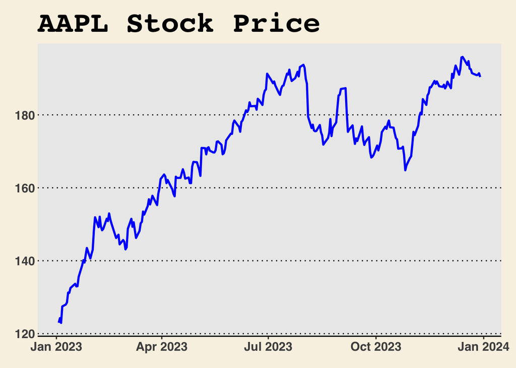

```r
# Plot price trend
ggplot(apple_stock, aes(x = date, y = adjusted)) +
  geom_line(color = "blue", linewidth = 1) +
  labs(title = "AAPL Stock Price", x = "Date", y = "Adjusted Close") +
  theme_wsj()
```

## 9. Interactive Visualization with `highcharter`

More pre-built themes of hicharter can be found via *highcharter Themes and Styles**.*

```r
# Create interactive stock price and volume plot
highchart(type = "stock") |>
  hc_add_series(apple_stock, type = "line", hcaes(x = date, y = adjusted), name = "AAPL Price") |>
  hc_add_series(apple_stock, type = "column", hcaes(x = date, y = volume), name = "Trading Volume", yAxis = 1) |>
  hc_yAxis_multiples(
    list(title = list(text = "Stock Price")),
    list(title = list(text = "Trading Volume"), opposite = TRUE)
  ) |>
  hc_title(text = "AAPL Stock Price and Trading Volume") |>
  hc_add_theme(hc_theme_ft())
```

[interactive chart not shown]

```r
# Candlestick Chart
highchart(type = "stock") |>
  hc_add_series(apple_stock, type = "candlestick", hcaes(x = date, open = open, high = high, low = low, close = adjusted), name = "AAPL Price") |>
  hc_title(text = "AAPL Candlestick Chart")
```

[interactive chart not shown]

## Exercises

1. Fetch stock price data for **MSFT** using `tidyquant`.
2. Compute daily returns for MSFT.
3. Create a price trend plot for MSFT.
4. Create a **vector, matrix, and data frame**, and perform calculations on them.
5. Use **`highcharter`** to plot **MSFT price and trading volume**.

## Resources

1. [Cookbook for R](http://www.cookbook-r.com/).
2. [R Workflow](https://hbiostat.org/rflow/).
3. GenAI: ChatGPT, Gemini, etc.
4. [Data Analysis with R](https://www.coursera.org/specializations/statistics), Coursera, [Mine Çetinkaya-Rundel](https://www.coursera.org/instructor/minecetinkayarundel), Duke University.
5. [Google Data Analytics](https://www.coursera.org/professional-certificates/google-data-analytics), Coursera, Google.
6. [Stack Overflow](https://stackoverflow.com/questions) for coding Q&A!

Happy coding! 🚀

Back to top